# Consultation Project | iMac & MacBook Pro

## Appropriateness of the above Regression

A check on the appropriateness of the model shows some question only on the part of the Q-Q Plot. The Q-Q plot seems to show slight irregularity (possible heavy-tailed granted there is more data points) on the ends. From these violations to Assumption #2 of the five assumptions, it is safe to assume that the regression is not as trustworthy. The plots below demonstrate this difficulty.

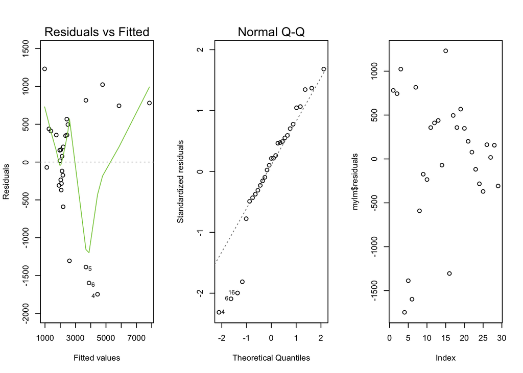

```r
par(mfrow=c(1,3))
plot(mylm,which=1:2)
plot(mylm$residuals)
```

## The Data

Here is the data from the experiment for those interested.

```r
Mac <- select(Computers, c(Models, Processor, CPUmulti_Scores, Price))
pander(Mac)
```

| Models | Processor | CPUmulti_Scores | Price |
| --- | --- | --- | --- |
| iMac Pro (Late 2017) | Intel Xeon W-2191B | 13439 | 8629 |
| iMac Pro (Late 2017) | Intel Xeon W-2170B | 10838 | 6599 |
| iMac Pro (Late 2017) | Intel Xeon W-2150B | 9429 | 5799 |
| iMac (27-inch Retina Mid 2020) | Intel Core i9 | 9000 | 2699 |
| iMac (27-inch Retina Mid 2020) | Intel Core i7 | 8008 | 2299 |
| iMac (27-inch Retina Early 2019) | Intel Core i9 | 8270 | 2289 |
| iMac Pro (Late 2017) | Intel Xeon W-2140B | 8003 | 4499 |
| iMac (21.5-inch Retina Early 2019) | Intel Core i7-8700 | 6055 | 1599 |
| iMac (27-inch Retina Mid 2020) | Intel Core i5-10600 | 6033 | 1999 |
| iMac (27-inch Retina Mid 2020) | Intel Core i5-10500 | 5851 | 1799 |
| iMac (27-inch Retina Early 2019) | Intel Core i5-9600K | 5470 | 2099 |
| iMac (27-inch Retina Early 2019) | Intel Core i5-8600 | 5009 | 1799 |
| iMac (27-inch Retina Early 2019) | Intel Core i5-8500 | 4842 | 1699 |
| iMac (21.5-inch Retina Early 2019) | Intel Core i5-8500 | 4658 | 1049 |
| iMac (27-inch Retina Mid 2017) | Intel Core i7-7700K | 4472 | 2209 |
| MacBook Pro (13-inch Late 2020) | Apple M1 | 7377 | 1299 |
| MacBook Pro (16-inch Late 2019) | Intel Core i9-9980HK | 6868 | 2999 |
| MacBook Pro (16-inch Late 2019) | Intel Core i9-99880H | 6555 | 2799 |
| MacBook Pro (15-inch Mid 2019) | Intel Core i9-9980HK | 6506 | 2999 |
| MacBook Pro (15-inch Mid 2019) | Intel Core i9-9880H | 6098 | 2699 |
| MacBook Pro (16-inch Late 2019) | Intel Core i7-9750H | 5331 | 2399 |
| MacBook Pro (15-inch Mid 2019) | Intel Core i7-9750H | 4945 | 2199 |
| MacBook Pro (15-inch Mid 2018) | Intel Core i9-8950HK | 4928 | 2000 |
| MacBook Pro (15-inch Mid 2018) | Intel Core i7-8850H | 4746 | 1799 |
| MacBook Pro (15-inch Mid 2018) | Intel Core i7-8750H | 4657 | 1694 |
| MacBook Pro (13-inch Mid 2020) | Intel Core i7-1068NG7 | 4517 | 2199 |
| MacBook Pro (13-inch Mid 2020) | Intel Core i5-1038NG7 | 4239 | 1999 |
| MacBook Pro (13-inch Mid 2019) | Intel Core i7-8569U | 4171 | 2124 |
| MacBook Pro (13-inch Mid 2018) | Inter Core i7-8559U | 3916 | 1609 |